# An introduction to data visualization using ggplot2, part 2

2016-09-13

# Introduction

This file introduces basic concepts of plotting using the ggplot2 package, which implements grammar of graphics. This is a coherent system for describing and building graphs in R. This is the the second part of the tutorial, which covers the remaining 3 parts of the grammar - statistical transformations, position adjustments and coordinate systems.

Code chunks below can be executed by clicking the *Run* button within the chunk or by placing your cursor inside it and pressing *Ctrl+Shift+Enter*.

```r
library(ggplot2)
suppressMessages(library(dplyr))
```

You will continiue to work with two built-in datasets - `mpg` and `diamonds`.

```r
# Fuel efficiency dataset:
data(mpg)

# Diamonds dataset:
data(diamonds)
```

# A graphing template (reminder)

To create a graph, you are combining one or more *layers*. Each layer is formed by a *geom* (geometric object). The visual properties of geoms (or *aesthetics*) are *mapped* to variables in a dataset. A *scale* controls how the values of a variable are mapped to the levels of an aesthetic. Finally, the graph can be decomposed into several panels based on the values of a categorical variable. This process is known as *faceting*. The template for plotting is therefore:

```r
ggplot(data = <DATA>) +
  <GEOM_FUNCTION>(mapping = aes(<MAPPINGS>)) +
  ... +
  <SCALE_FUNCTION> +
  <FACET_FUCTION>
```

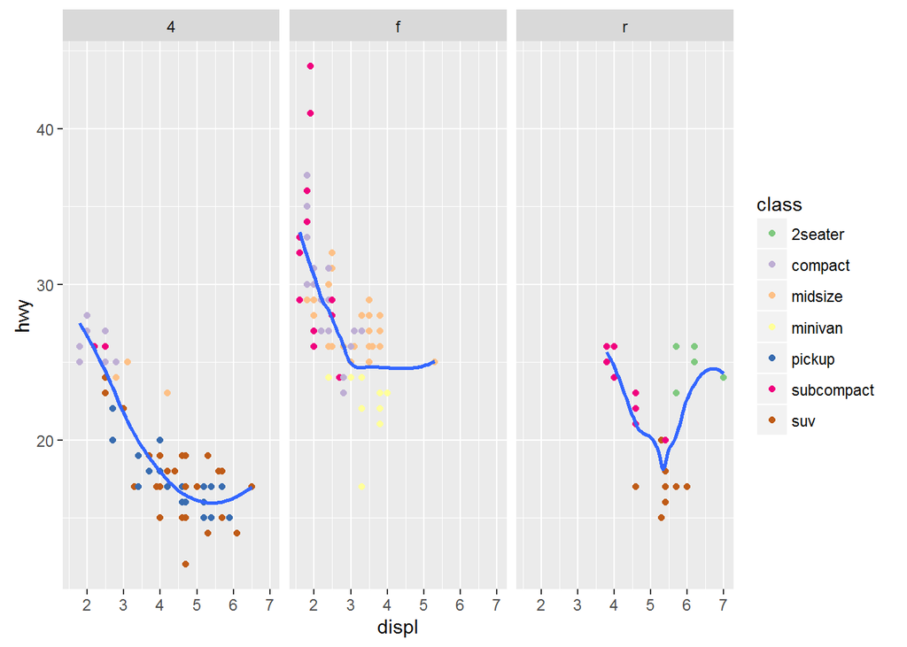

```r
ggplot(data = mpg) +
  geom_point(mapping = aes(x = displ, y = hwy, color = class)) +
  geom_smooth(mapping = aes(x = displ, y = hwy), se = FALSE) +
  scale_color_brewer(palette = 'Accent') +
  facet_wrap(~drv)
```

A cheat sheet for geoms and their aesthetics is [available](http://r4ds.had.co.nz/images/visualization-geoms-3.png).

# Default mappings and local overrides

The template we’ve been using so far is quite wordy. You can significantly reduce the effort by moving the mappings common to all the layers into the default mappings, provided in the `ggplot()` function call. Mappings, that are unique to specific levels can be provided in the geom functions as needed.

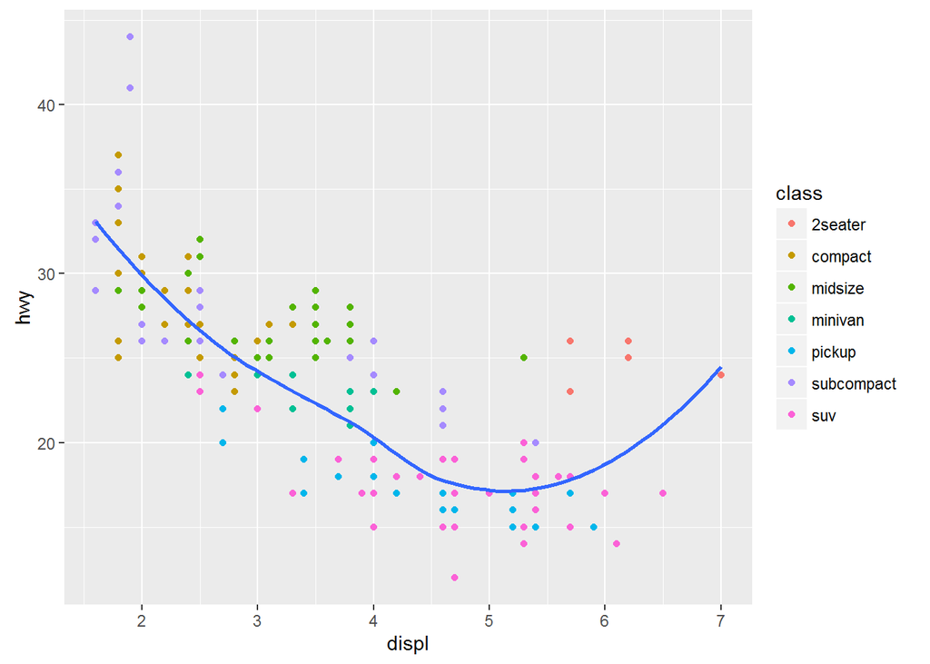

```r
ggplot(data = mpg, mapping = aes(x = displ, y = hwy)) +
  geom_point(mapping = aes(color = class)) +
  geom_smooth(se = FALSE)
```

Not only mappings, but also data can be overriden in a geom function for a particular layer. Let’s highlight the cars manufactured by Dodge, for example:

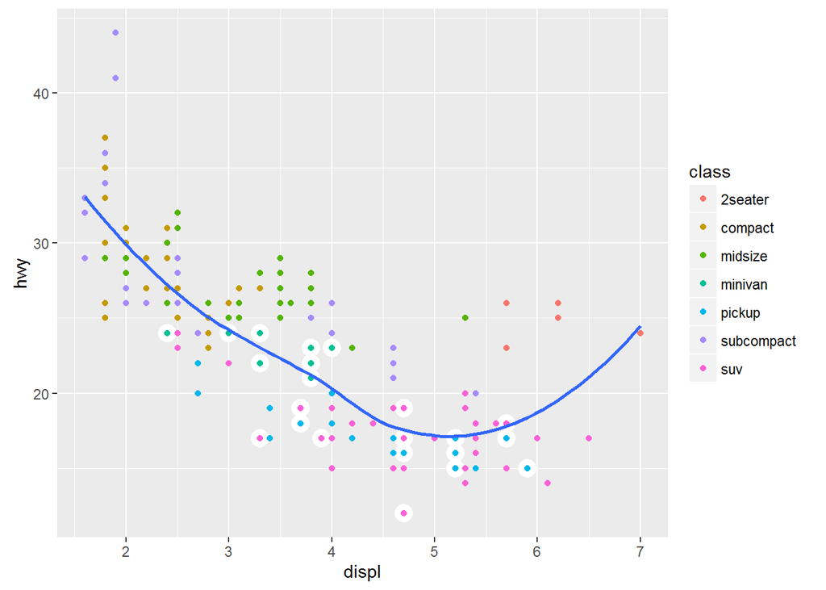

```r
ggplot(data = mpg, mapping = aes(x = displ, y = hwy)) +
  geom_point(data = filter(mpg, manufacturer == 'dodge'),
             color = 'white', size = 5) +
  geom_point(mapping = aes(color = class)) +
  geom_smooth(se = FALSE)
```

Here we are providing a separate dataset, containing only cars by Dodge to the `geom_point()` function in the first layer. Two next layers use the default dataset, provided in the `ggplot()` call.

# Statistical transformations

Let’s take a look at a bar chart. This plot type is widely used to visualize a distribution of a discrete variable, or to compare groups based on some descriptive statistics.

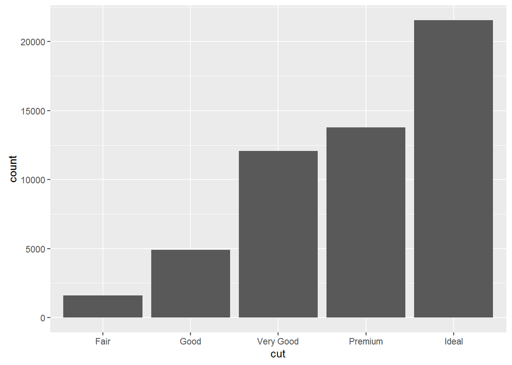

```r
ggplot(data = diamonds) +
  geom_bar(mapping = aes(x = cut))
```

```r
names(diamonds)
```

```
##  [1] "carat"   "cut"     "color"   "clarity" "depth"   "table"   "price"
##  [8] "x"       "y"       "z"
```

As you can see, the x-axis is using a variable from the `diamonds` dataset. But the `count` variable isn’t there. In contrast to scatterplots, which use raw data, bar plot first splits a dataset based on the values of the variable for the x-aesthetic, and then applies a *statistical transformation* function to get counts for each group. The short name for a statistical transformation in ggplot2 package is *stat*.

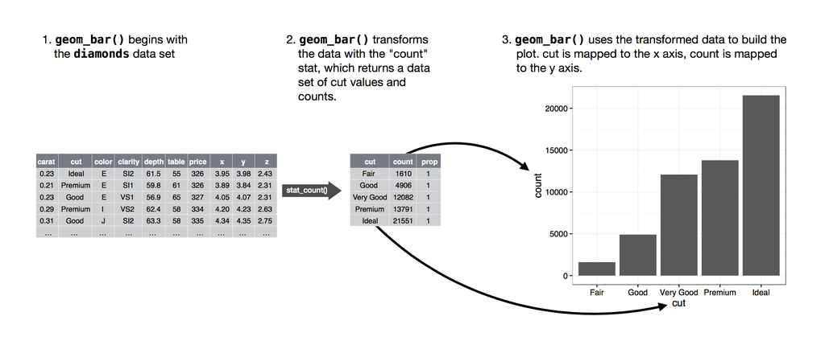

Statistical transformations

Other graphs also need to apply statistical transformations to data:

- *bar charts*, *histogtams*, *frequency polygons* bin the data first and then plot bin counts
- *smoothers* fit a model to the data and then plot predictions from the model
- *box plots* calculate the quartiles of the data and then plot the quartiles as a box

Each geom in ggplot2 is associated with a default stat, that is automatically called to prepare values for a plot. If a geom needs raw data, the *identity transformation* is applied, so the `stat_identity()` function is called anyway. This transformation however leaves the input data intact. So the process for the `geom_point()` is the same.

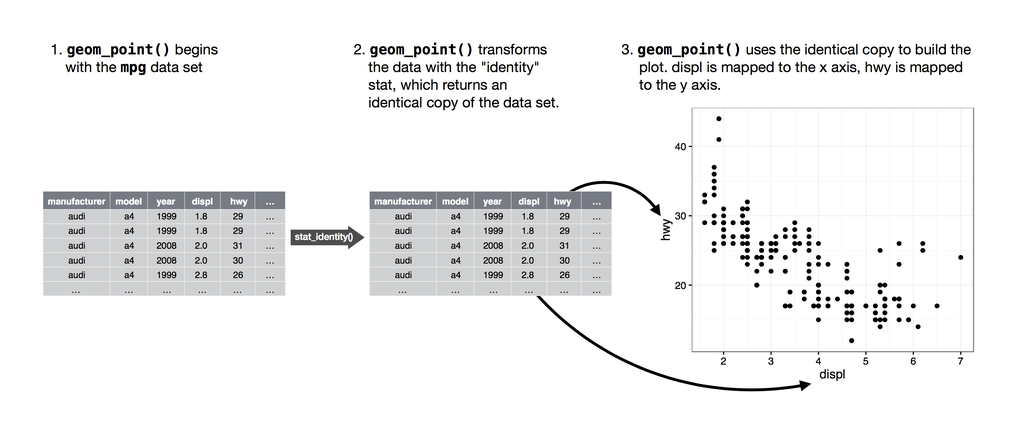

Identity transformation for a geom

# Overriding default transformation and mappings

You might want to override the default mapping from transformed variables to aesthetics. For example, a mapping in a bar plot can be changed to display proportions rather than count. The computed variable’s name is surrounded by dots to distinguish it from the variables in the original data:

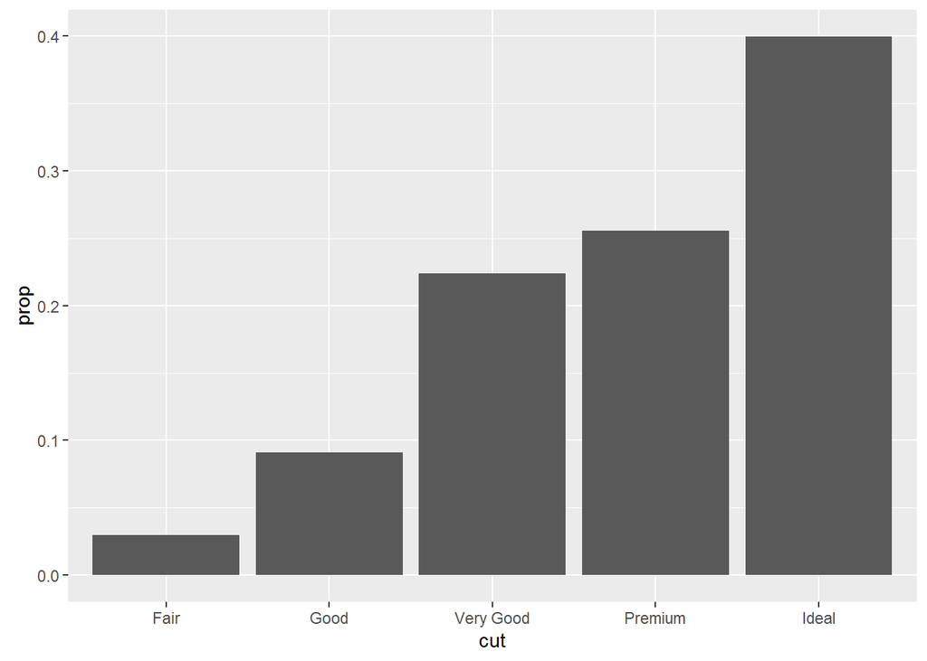

```r
ggplot(data = diamonds) +
  geom_bar(mapping = aes(x = cut, y = ..prop.., group = 1))
```

```r
# We need group = 1 here to use all data to compute proportions for each group. Otherwise, the proportions are calculated for each category independently, and thus are all equal to 1.
```

A second case when you might want to change the default behaviour of a geom is to replace the stat function itself. For example, you may want to use raw data to control the height of bars in a bar plot instead of counts. In this case you’ll need to replace the default stat with the identity transformation.

Let’s compute and plot the average mileage for cars of each class.

```r
# Compute average mileage for each car class
class_mpg <- summarize(group_by(mpg, class), avg_hwy = mean(hwy))
class_mpg
```

```
## # A tibble: 7 × 2
##        class  avg_hwy
##        <chr>    <dbl>
## 1    2seater 24.80000
## 2    compact 28.29787
## 3    midsize 27.29268
## 4    minivan 22.36364
## 5     pickup 16.87879
## 6 subcompact 28.14286
## 7        suv 18.12903
```

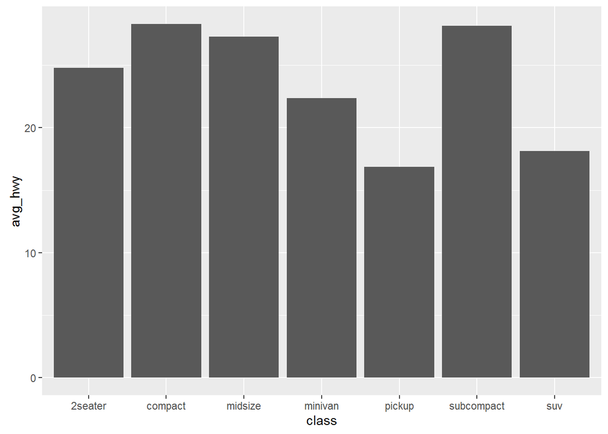

```r
# Plot average mileage
ggplot(data = class_mpg) +
  geom_bar(mapping = aes(x = class, y = avg_hwy), stat = "identity")
```

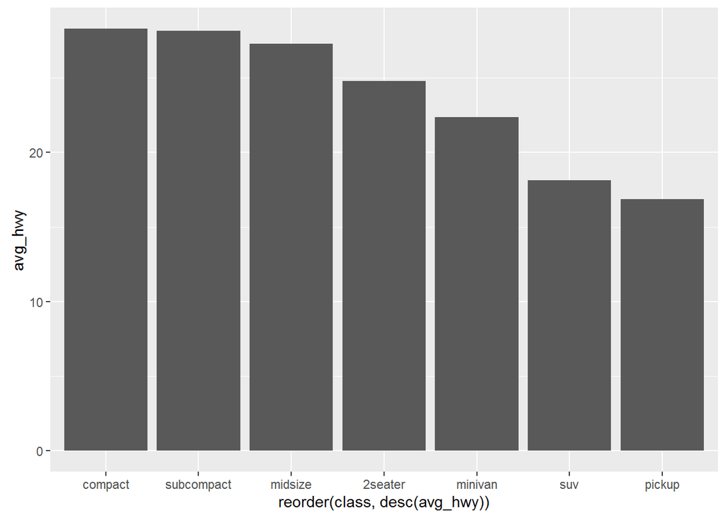

```r
# Plot average mileage, order by descending average highway mileage
ggplot(data = class_mpg) +
  geom_bar(mapping =
             aes(x = reorder(class, desc(avg_hwy)), y = avg_hwy),
           stat = "identity")
```

# Plotting functions

Package ggplot2 provides many stats for you to use. A cheat sheet with avialiable stats is available [here](http://r4ds.had.co.nz/images/visualization-stats.png).

Each stat is available as a function which provides a convenient way to access a stat’s help page (e.g. `?stat_function`). Since each stat function is associated with a default geom, you can add them directly as layers for your plot.

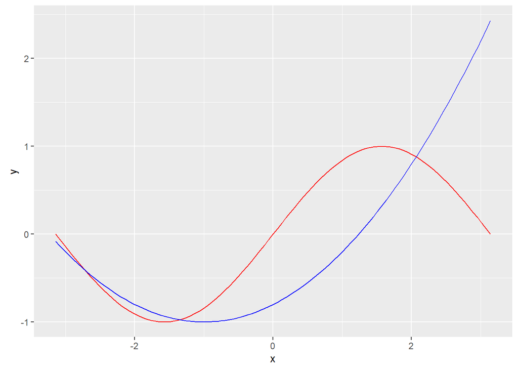

```r
ggplot(data = tibble(x = c(-pi, pi)), mapping = aes(x)) +
  stat_function(fun = sin, color = 'red') +
  stat_function(fun = function(x) { 0.2 * (x + 1)^2 - 1}, color = 'blue')
```

You can overlay function plots on top of data. Let’s overlay a normal density function on top of city mileage to compare, if it fits the data well. R has a built-in `dnorm()` function to compute the normal density. It’s parameters are the mean and the standard deviation.

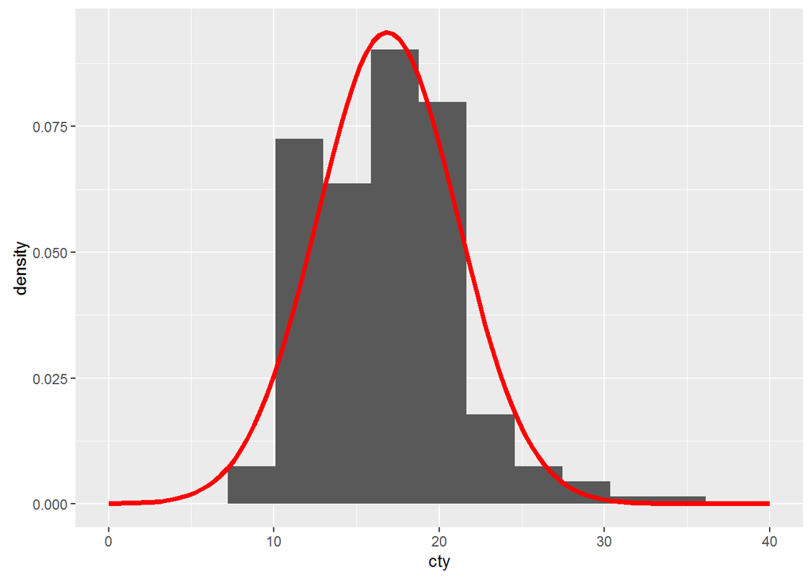

```r
# Compute parameters for the normal distribution
params <- list(mean = mean(mpg$cty), sd = sd(mpg$cty))

# Plot data and the density function
ggplot(data = mpg, mapping = aes(x = cty)) +
  geom_histogram(mapping = aes(y = ..density..), bins = 10) +
  stat_function(fun = dnorm, args = params, xlim = c(0, 40),
                color = 'red', size = 1.5)
```

## Exercise - plotting distribution of diamond prices

Plot a histogram of diamond prices based on the `diamonds` dataset. Try to recreate the plot:

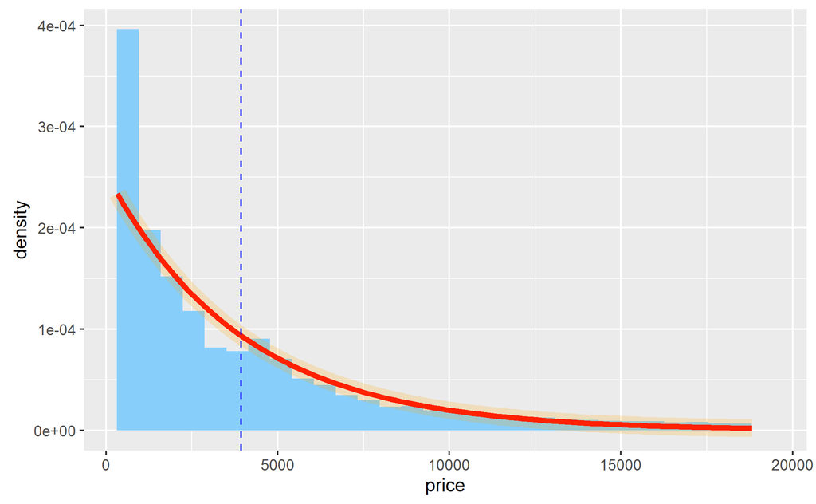

Histogram of diamond prices

A list of color names available in R can be found [here](http://www.stat.columbia.edu/~tzheng/files/Rcolor.pdf)

The density function for this distribution is the exponential density function:

$$f(x) = \lambda e^{-\lambda x}$$

where $\lambda$ is the *rate* parameter. You can estimate rate from the data using the formula:
$$\lambda = 1 / \bar{x}$$

Define your own function with two arguments: x and rate, or use the built-in exponential density function - `dexp()`. See `?dexp`.

The vertical reference line is positioned at the average price. See `?vline` for help on how to add it.

```r
# Your code here
```

# Position adjustments

## Bar charts

Bar charts are commonly used to display the interaction between two or more categorical variables. You can plot interactions by mapping these variables to different aesthetics. For example, you can plot the counts for each combination of `cut` and `clarity` variables:

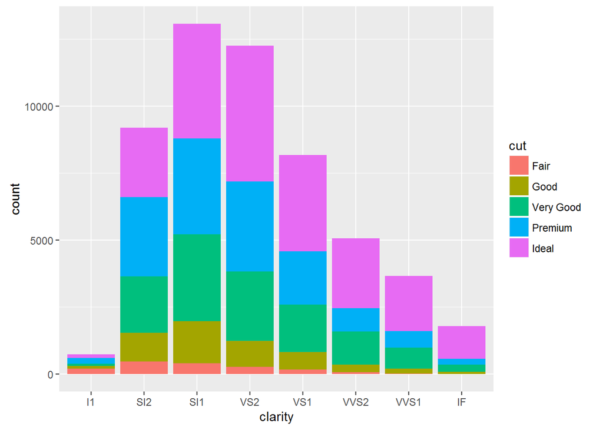

```r
ggplot(data = diamonds) +
  geom_bar(mapping = aes(x = clarity, fill = cut))
```

By default, the bars are automatically stacked. Each colored rectangle is a combination of different cut types for a given clarity grade. Other options can be selected by the position adjustment using the `position =` argument.

- `postition = identity` will place each object on top of the others. It’s not so useful for bars, since it overlaps them.

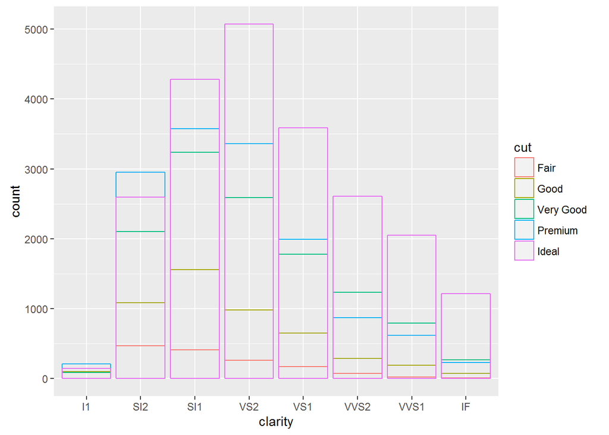

```r
ggplot(data = diamonds) +
  geom_bar(mapping = aes(x = clarity, color = cut),
           position = 'identity',
           fill = NA) #disable fill
```

The identity position is more useful for 2d geoms, like points, where it is the default.

- `position = fill` works like stacking, but it normalizes each set of stacked bars to the same height. This makes it easier to compare proportions across groups.

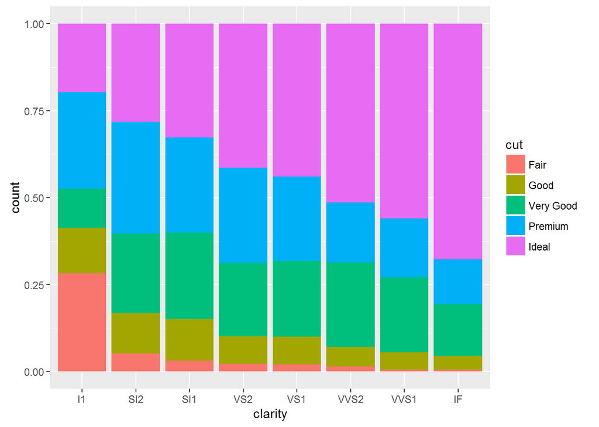

```r
ggplot(data = diamonds) +
  geom_bar(mapping = aes(x = clarity, fill = cut),
           position = 'fill')
```

- `position = dodge` places bars directly beside one another. This makes it easier to compare individual values.

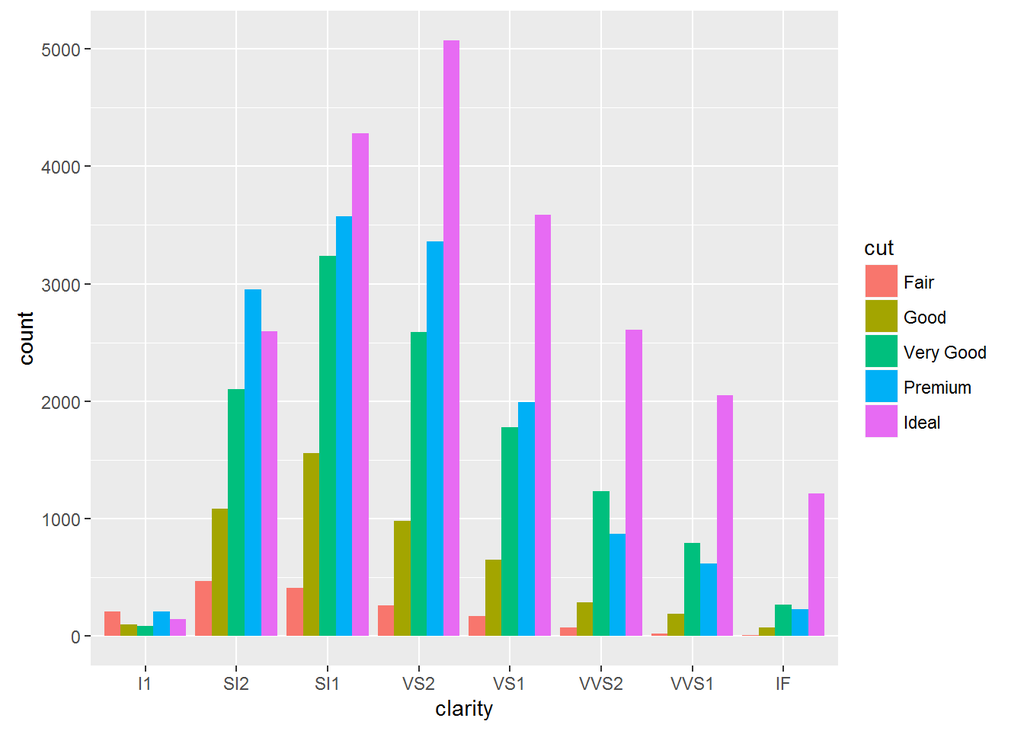

```r
ggplot(data = diamonds) +
  geom_bar(mapping = aes(x = clarity, fill = cut),
           position = 'dodge')
```

## Scatterplots

The other type of adjustment is useful for scatterplots. Sometimes you can’t see how much data is plotted due to *overplotting*, when the points are exactly on top of each other.

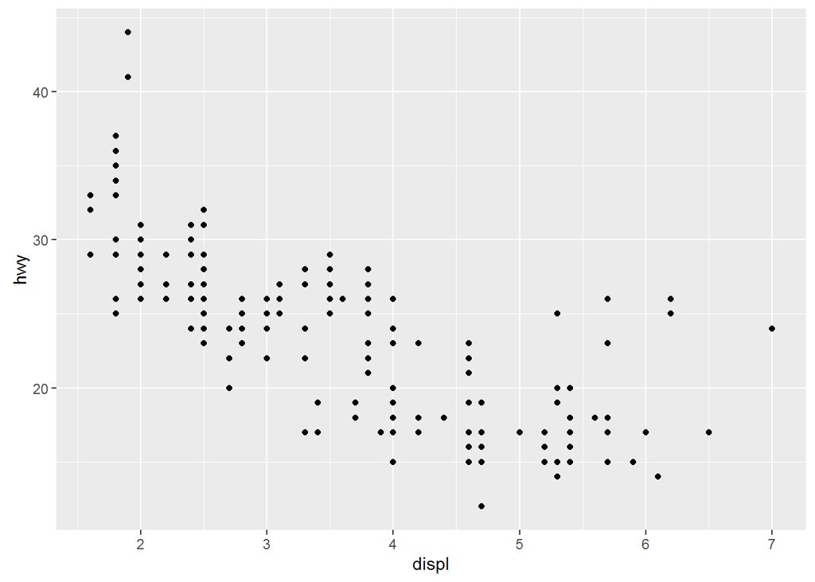

```r
ggplot(data = mpg) +
  geom_point(mapping = aes(x = displ, y = hwy))
```

This is due to the values of `hwy` and `disp` are rounded and appear on a grid.

You can avoid overplotting by introducing some random noise to point’s positions. This is done by using the `position = jitter` adjustment.

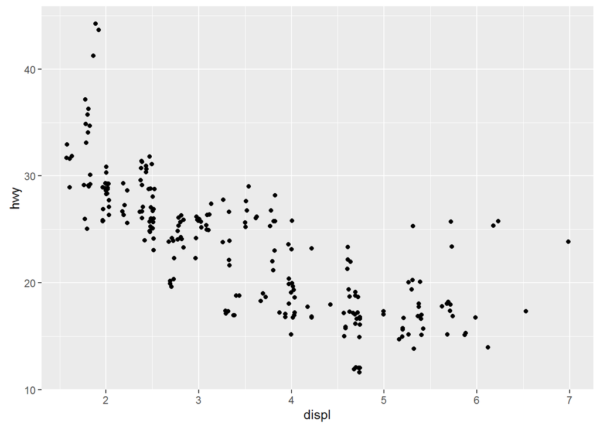

```r
ggplot(data = mpg) +
  geom_point(mapping = aes(x = displ, y = hwy),
             position = 'jitter')
```

You can see much more points now. To simplify jittering operation, ggplot2 includes a shortcut for `geom_point(position = 'jitter'): geom_jitter()`

More information about a position adjustment is available in the help pages: `?position_dodge`, `?position_fill`, `?position_identity`, `?position_jitter`, `?position_stack`.

# Coordinate systems

Coordinate systems control how the data is plotted. They map objects’ positions to the screen coordinates. For now, we’ll consider just a couple of examples, where adjustments for coordinate systems are helpful.

## Flipping coordinates

The `coord_flip()` function switches x and y axes. This is useful if you want the categories on a box or a bar plot on the y axis to improve readability.

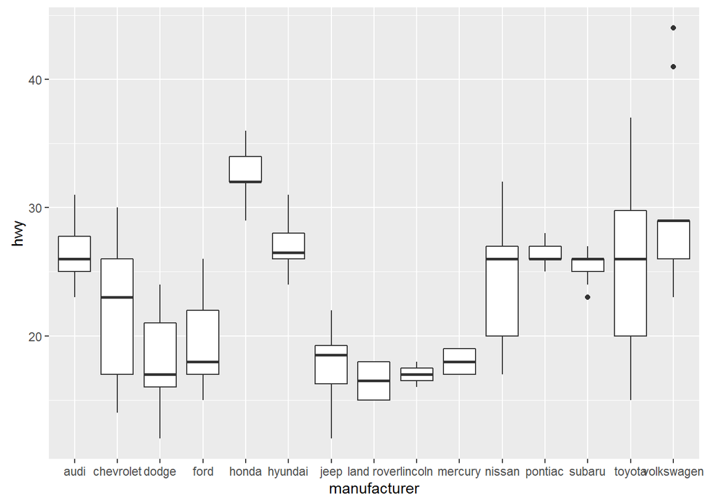

```r
# Default behavior
ggplot(data = mpg, mapping = aes(x = manufacturer, y = hwy)) +
  geom_boxplot()
```

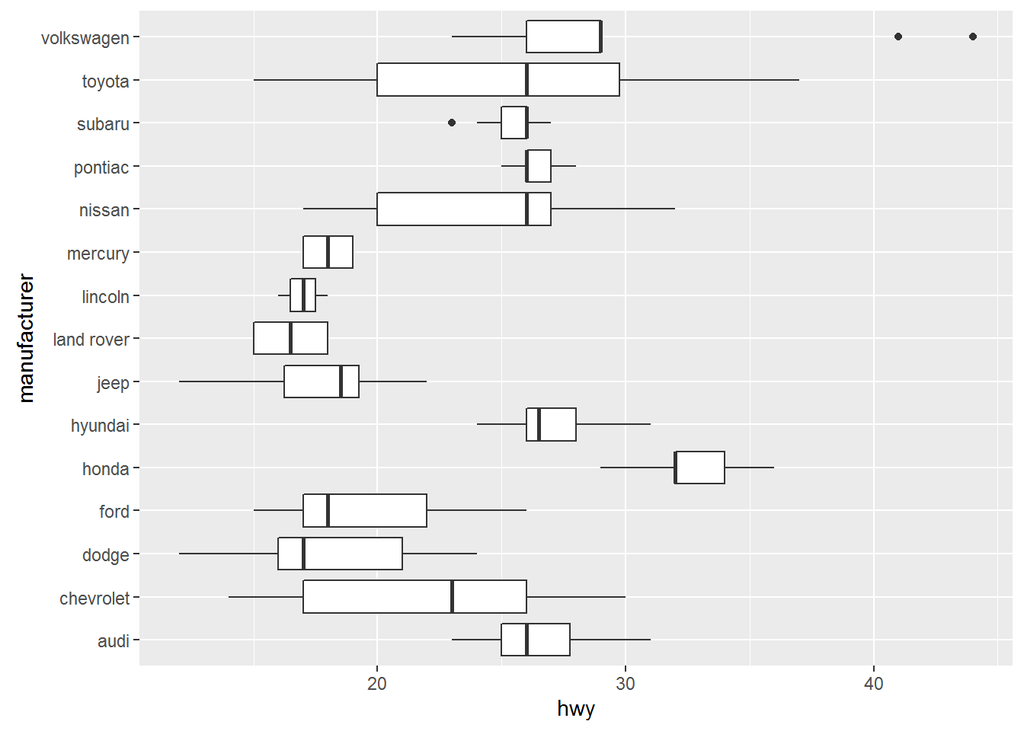

```r
# Flipping coordinates to improve label readability
ggplot(data = mpg, mapping = aes(x = manufacturer, y = hwy)) +
  geom_boxplot() +
  coord_flip()
```

## Setting axis limits

The second case when tweaking a coordinate system is necessary is setting limits for an axis.

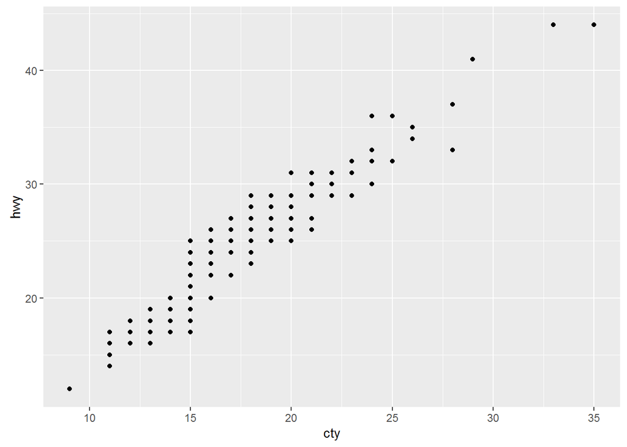

```r
# Default behavior
ggplot(data = mpg, mapping = aes(x = cty, y = hwy)) +
  geom_point()
```

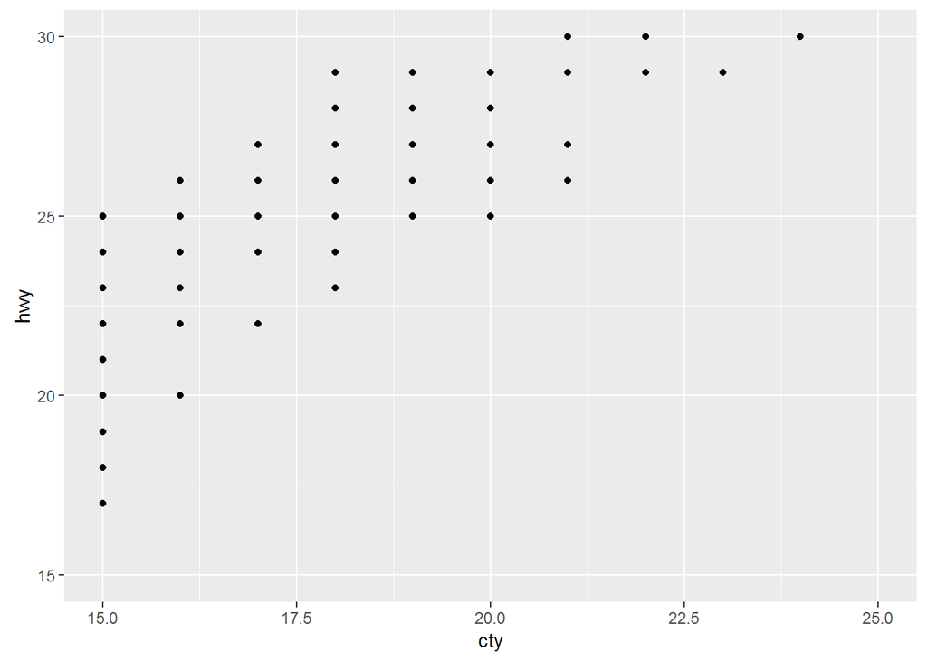

```r
# Zooming-in on a range
ggplot(data = mpg, mapping = aes(x = cty, y = hwy)) +
  geom_point() +
  coord_cartesian(xlim = c(15, 25), ylim = c(15, 30))
```

# Exercise - putting it all together

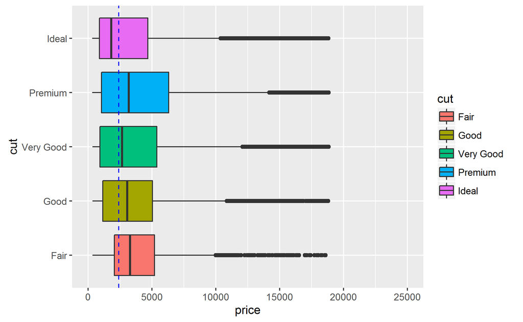

The dashed line is median price for all diamonds.

```r
# Your code here
```